# S02 T02: Estructura d'una Matriu

Treballem els conceptes de l'estructura d'una matriu, dimensió, eixos i la vectorització que ens permet reduir l'ús de for loops en operacions aritmètiques o matemàtiques..

### Exercici 1

#### Crea un np.array d'una dimensió, que inclogui l'almenys 8 nombres sencers, data type int64. Mostra la dimensió i la forma de la matriu. .

```python
import numpy as np
array1 = np.array([1, 2, 3, 4, 5, 15, 22, 45, 36, 56], dtype = np.int64)
print("dimensió",array1.ndim)
print("forma",array1, array1.dtype)
```

```
dimensió 1
forma [ 1  2  3  4  5 15 22 45 36 56] int64
```

### Exercici 2

#### De la matriu de l'exercici 1, calcula el valor mitjà dels valors introduïts i resta la mitjana resultant de cada un dels valors de la matriu.

```python
print("mitja",array1.mean()/len(array1))
e = np.full((1,len(array1)),array1.mean()/len(array1))
print(array1 - e)
```

```
mitja 1.89
[[-0.89  0.11  1.11  2.11  3.11 13.11 20.11 43.11 34.11 54.11]]
```

### Exercici 3

#### Crea una matriu bidimensional amb una forma de 5 x 5. Extreu el valor màxim de la matriu, i els valors màxims de cadascun dels seus eixos.

```python
matrix1 = np.random.random((5,5))
print(matrix1)
print("Valor máximo de la matriz:",matrix1.max() )
a = len(matrix1)
ejes = [matrix1[0][a-1], matrix1[0][0], matrix1[a-1][a-1], matrix1[a-1][0]]
print("Valor máximo de los ejes de la matriz:", max(ejes))
```

```
[[0.1336448  0.48628173 0.02503304 0.349093   0.66977481]
 [0.01035916 0.09566501 0.37133039 0.36636353 0.15500168]
 [0.61377908 0.71886373 0.57697732 0.52801327 0.6159866 ]
 [0.19948002 0.68820586 0.94587733 0.11979025 0.71371467]
 [0.31087864 0.91654098 0.46154961 0.72713488 0.81594635]]
Valor máximo de la matriz: 0.9458773267984644
Valor máximo de los ejes de la matriz: 0.8159463504302026
```

Treballem els conceptes de l'estructura d'una matriu, Broadcasting, indexació, Mask..

### Exercici 4

#### Mostreu-me amb exemples de diferents matrius, la regla fonamental de Broadcasting que diu : "les matrius es poden transmetre / broadcast si les seves dimensions coincideixen o si una de les matrius té una mida d'1".

```python
matrix2 = np.array([[2,9],[6,1]])
matrix3 = np.array([[1]])
matrix4 = np.array([[2,5]])
print(matrix2)
print(matrix2-matrix3)
print(matrix2-matrix4)
```

```
[[2 9]
 [6 1]]
[[1 8]
 [5 0]]
[[ 0  4]
 [ 4 -4]]
```

### Exercici 5

#### Utilitza la Indexació per extreure els valors d'una columna i una fila de la matriu. I suma els seus valors.

```python
import numpy as np
matrix5 = np.array([[2,9,8],[6,1,9],[2,5,3]])
fila = 0
for i in matrix5:
    sumCol = 0
    sumFila = 0
    col = 0
    for j in i:
        sumFila += matrix5[fila][col]
        sumCol += matrix5[col][fila]
        col += 1

    fila += 1
    print("Fila {}: {}".format(fila,sumFila))
    print("Columna {}: {}".format(fila,sumCol))
    break
```

```
Fila 1: 19
Columna 1: 10
```

### Exercici 6

#### Mask la matriu anterior, realitzeu un càlcul booleà vectoritzat, agafant cada element i comprovant si es divideix uniformement per quatre.

#### Això retorna una matriu de mask de la mateixa forma amb els resultats elementals del càlcul.

```python
res = matrix5%4
print(res)
matrix6 = np.array(res, dtype = bool)
fila = 0
for i in matrix6:
    col = 0
    for j in i:
        if res[fila][col] == 0: matrix6[fila][col] = True
        else: matrix6[fila][col] = False
        col += 1
    fila += 1
print(matrix6)
```

```
[[2 1 0]
 [2 1 1]
 [2 1 3]]
[[False False  True]
 [False False False]
 [False False False]]
```

### Exercici 7

Manipulació d’imatges amb Matplotlib.

Carregareu qualsevol imatge (jpg, png ..) amb Matplotlib. adoneu-vos que les imatges RGB (Red, Green, Blue) són realment només amplades × alçades × 3 matrius (tres canals Vermell, Verd i Blau), una per cada color de nombres enters int8,

manipuleu aquests bytes i torneu a utilitzar Matplotlib per desar la imatge modificada un cop hàgiu acabat.

### Exercici 8

#### Mostreu-me a veure què passa quan eliminem el canal G Verd o B Blau. Hauries d'utilitzar la indexació per seleccionar el canal que voleu anul·lar.

#### Utilitzar el mètode, mpimg.imsave () de la llibreria importada, per guardar les imatges modificades i que haureu de pujar al vostre repositori a github.

[output not shown]

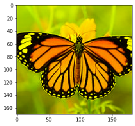

```python
import matplotlib.image as mpimg
import matplotlib.pyplot as plt
img = mpimg.imread("imag.jfif")
print(img)
pixels = np.array(img)
pixels1 = np.array(img)
for x in range(0,len(pixels)):
    for y in range(0,len(pixels[0])):
        rgb = pixels[x][y]
        rgb[0] = rgb[0] #canal vermell
        rgb[1] = 0 #canal verd
        rgb[2] = rgb[2] #canal blau
        pixels[x][y] = rgb

imgplot = plt.imshow(pixels)
mpimg.imsave("imagen1.jpg", pixels)

for x in range(0,len(pixels)):
    for y in range(0,len(pixels[0])):
        rgb = pixels1[x][y]
        rgb[0] = rgb[0] #canal vermell
        rgb[1] = rgb[1] #canal verd
        rgb[2] = 0 #canal blau
        pixels1[x][y] = rgb

imgplot = plt.imshow(pixels1)
mpimg.imsave("imagen2.jpg", pixels1)
```